# To Live Longer, What We Should Do?

2000692

1/3/2021

# Abstract

# Data

We concentrate on nationals of OECD countries in year 2017. We retrieved the data from OECD data set, which include indicators such as housing expenditure, employment rate, years in education, air pollution and so forth. These official data have quite high quality, so measurement error can be neglected.

To keep our study precise, we removed variables with less than 40 observations; in the end, we obtained 9 variables: country names, life expectancy, employment rate, air pollution, water quality, supportive network, voter turnout, safety of walking at night and homicide. In the examination of these variables, we found some extreme values in homicide rate, which will affect our regression result, considering the size of our sample(40 observations, only). So, we decide not to drop these 5 values, but rather replace them with mean value of remaining 35 observations.

We intend to find the association of pattern between life expectancy and other factors. Our aim, is to find which factor contribute most to people’s life span. Thus, we will analyze the statistics of these variables and build our model.

The following table shows the descriptive statistics of these variables. As we notice, 3/4 of our variables(except air pollution and life expectancy) are in percentage unit, which can not offer us further relative differences even if log transformation is applied. We also check all histograms, most of which do not have right-tailed pattern, except one, the homicide rate.

Summary Statistics of Variables

| Name | n | Min | 1st IQR | Median | 3rd IQR | Max | Mean | Std. | Skew |
| --- | --- | --- | --- | --- | --- | --- | --- | --- | --- |
| Air pollution | 40 | 3.0 | 9.75 | 14.00 | 16.50 | 28.0 | 13.32 | 5.77 | 0.26 |
| Employment rate | 40 | 43.0 | 65.75 | 69.50 | 74.00 | 86.0 | 68.47 | 7.97 | -0.87 |
| Homicide rate | 40 | 0.2 | 0.60 | 0.95 | 2.12 | 26.7 | 3.43 | 6.33 | 2.64 |
| Life expectancy | 40 | 57.5 | 77.95 | 81.40 | 82.40 | 84.1 | 79.58 | 4.67 | -2.85 |
| Quality of support network | 40 | 78.0 | 88.00 | 91.00 | 93.00 | 98.0 | 90.12 | 4.30 | -0.86 |
| Voter turnout | 40 | 47.0 | 60.75 | 69.50 | 79.00 | 91.0 | 69.58 | 12.21 | -0.02 |
| Feeling safe walking alone at night | 40 | 35.6 | 59.95 | 70.30 | 78.43 | 90.1 | 68.25 | 14.02 | -0.67 |
| Water quality | 40 | 55.0 | 74.50 | 84.00 | 91.00 | 99.0 | 82.38 | 10.55 | -0.48 |

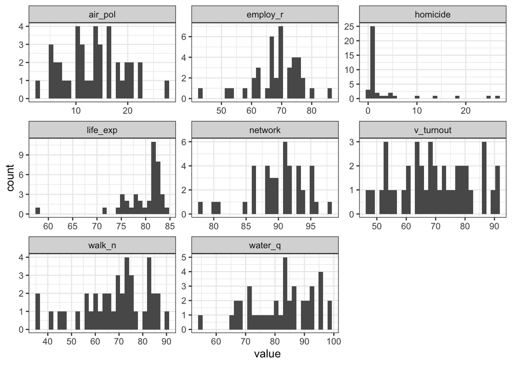

Recall the extreme values of homicide rate: considering the small size of our sample, obviously these extreme values will affect our regression result. However, if we simply remove these values, our sample size will become even smaller, and we will be further from precise result as well. So, we decide to replace these 5 extreme values with the mean value of homicide rate.

# Model

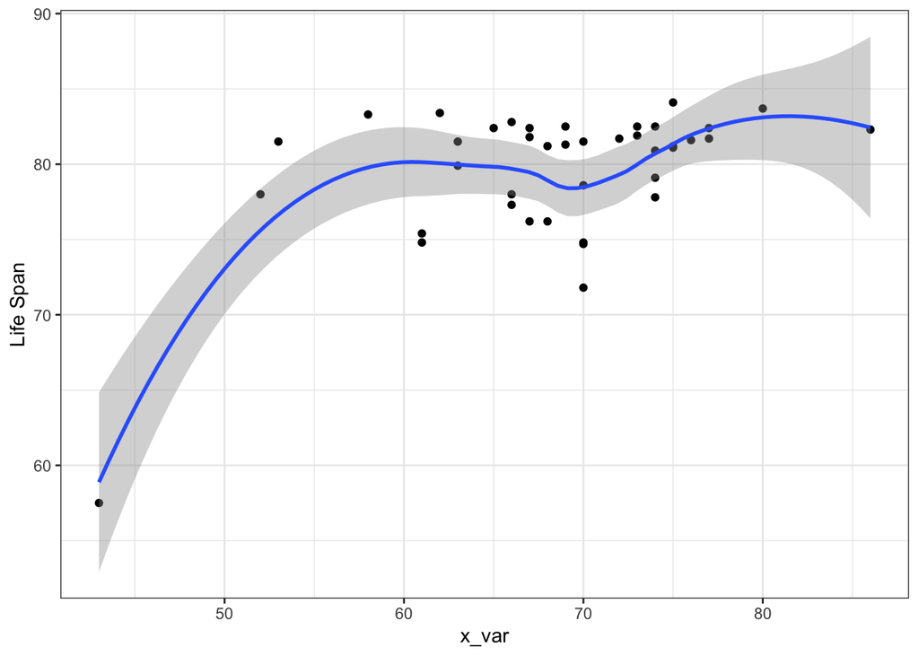

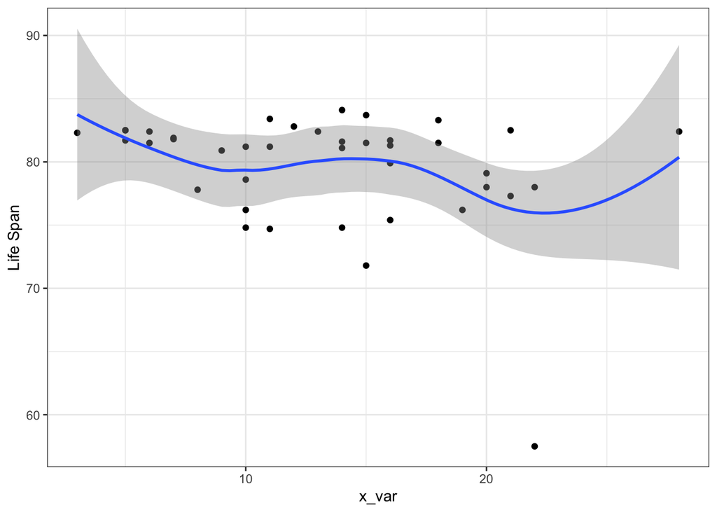

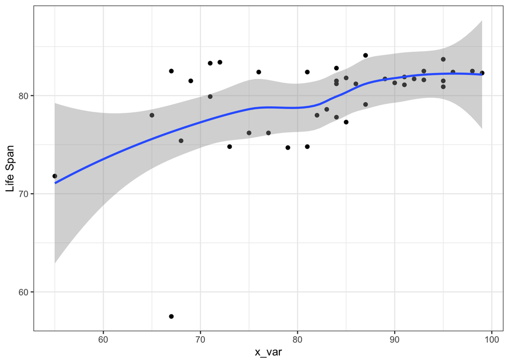

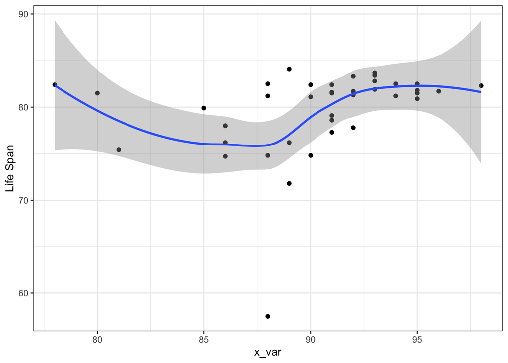

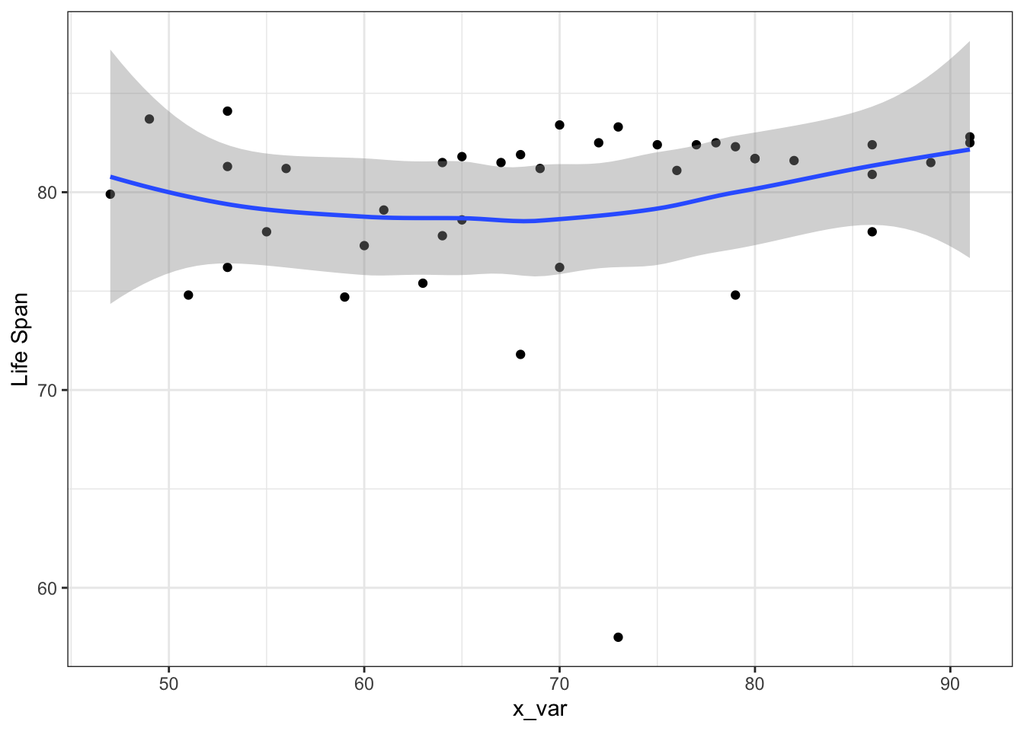

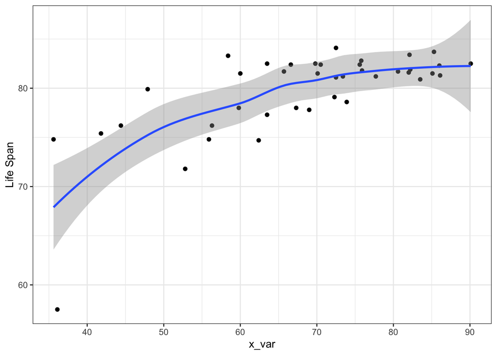

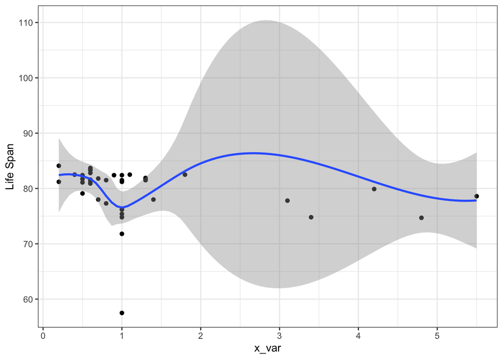

We try to capture this connection with a linear model:

*(life expectancy)E = beta0 + beta1(employment_rate) + beta2(air pollution) + beta3(water quality) + beta4 (supportive of network) + beta5(voter turnout) + beta6(feeling safe walking at night) + beta7(homicide rate)*

- same air pollution level, voter turnout rate and same percentage for feeling safe walking at night, people with ten percent higher water quality, on average, live less than 0.6 years.
- or, same same air pollution level, voter turnout rate and same level water quality, people with one higher percentage for feeling safe walking at night, on average, live more than 0.27 years.
- same air pollution level, same water quality and same percentage for feeling safe walking at night, people with ten percent higher voter turnout, on average, live less than 0.3 years.
- same voter turnout rate, same water quality and same percentage for feeling safe walking at night, people with ten percentage higher air pollution level, on average, live less than 0.5 years.

|  | Model 1 | Model 2 | Model 3 | Model 4 | Model 5 |
| --- | --- | --- | --- | --- | --- |
| (Intercept) | 97.57 *** | 97.63 *** | 62.30 *** | 68.65 *** | 66.81 *** |
|  | (19.93) | (20.49) | (11.87) | (8.17) | (5.92) |
| air_pol | -0.17 | -0.17 | -0.00 | -0.05 |  |
|  | (0.16) | (0.16) | (0.10) | (0.14) |  |
| employ_r | 0.15 | 0.15 | 0.14 |  |  |
|  | (0.25) | (0.25) | (0.27) |  |  |
| homicide | 0.01 |  |  |  |  |
|  | (0.90) |  |  |  |  |
| network | -0.43 | -0.43 |  |  |  |
|  | (0.33) | (0.33) |  |  |  |
| v_turnout | 0.01 | 0.01 | -0.01 | -0.03 | -0.02 |
|  | (0.04) | (0.04) | (0.05) | (0.06) | (0.06) |
| walk_n | 0.27 ** | 0.27 ** | 0.24 ** | 0.27 * | 0.27 * |
|  | (0.08) | (0.08) | (0.07) | (0.11) | (0.10) |
| water_q | -0.08 | -0.08 | -0.10 | -0.06 | -0.05 |
|  | (0.20) | (0.19) | (0.21) | (0.11) | (0.09) |
| nobs | 33 | 33 | 33 | 33 | 33 |
| r.squared | 0.59 | 0.59 | 0.53 | 0.51 | 0.51 |
| adj.r.squared | 0.48 | 0.50 | 0.45 | 0.44 | 0.46 |
| statistic | 3.17 | 3.80 | 4.29 | 3.53 | 4.37 |
| p.value | 0.02 | 0.01 | 0.01 | 0.02 | 0.01 |
| df.residual | 25.00 | 26.00 | 27.00 | 28.00 | 29.00 |
| nobs.1 | 33.00 | 33.00 | 33.00 | 33.00 | 33.00 |
| se_type | HC2.00 | HC2.00 | HC2.00 | HC2.00 | HC2.00 |
| *** p < 0.001; ** p < 0.01; * p < 0.05. |  |  |  |  |  |

# Residual Analysis

List of Coutnries with largest negative errors, Top 3

| Country | life_exp | exp_pred | reg4_res |
| --- | --- | --- | --- |
| Estonia | 77.8 | 80.14045 | -2.340450 |
| Russia | 71.8 | 77.09081 | -5.290814 |
| South Africa | 57.5 | 71.39627 | -13.896267 |

For these 3 countries, the model overestimated life expectancy, as the actual value is smaller than the predicted value; in another word, these countries have short life span than average. The explanation could be extreme weather(temperature) or worsened social safety conditions.

List of Coutnries with largest positive errors, Top 3

| Country | life_exp | exp_pred | reg4_res |
| --- | --- | --- | --- |
| Chile | 79.9 | 75.31331 | 4.586690 |
| Italy | 83.3 | 77.36488 | 5.935117 |
| Korea | 82.4 | 78.71501 | 3.684988 |

For these 3 countries, the model underestimated life expectancy, as the actual value is larger than the predicted value; in another word, these countries have longer life span than average. The explanation could be healthy(Mediterranean and Eastern Asian diet) or complete social security administration.

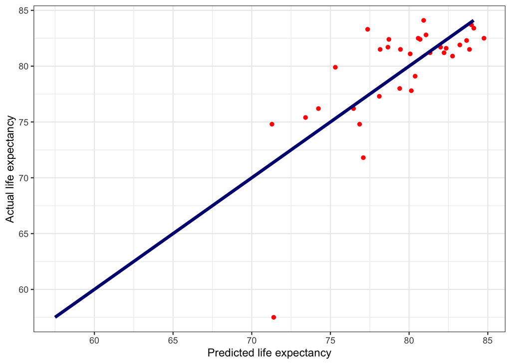

Also, we check the y and y_hat plot to examine the model fit. We can see that most scatters fall aside the line, indicating a good fit of the model.

# Prediction and Robustness analysis

We are concerned whether our analysis and model are true for other OECD countries; also, we wonder if the model we chose is truly “robust”. Therefore, we check for two alternative specification:

Also, we wonder whether our model performance will remain unchanged, taking interaction of explanatory variables and alternative models. First, we add interaction of air pollution and water quality as a new variable, which provides us with a new model. Also, from the scatter plot of life expectancy and air pollution, we find there are two “turning points” at x = 10 and 20; so we make a piecewise linear regression at these points, to see if this model will better fit the pattern.

prediction of regression model 4

| life_exp | exp_pred | reg4_res |
| --- | --- | --- |
| 81.5 | 79.92731 | 1.572687 |

As we can see from the figure, indeed using piecewise linear spline and interactions of certain x slightly increases R-square of the model, and they do not decrase p value of each variable to a significant degree. Furthermore, both models are more complicated to interpret. So, we decide to stick to the original model.

|  | Model 1 | Model 2 |
| --- | --- | --- |
| (Intercept) | 88.39 ** | 64.55 *** |
|  | (26.24) | (9.30) |
| air_pol | -1.53 |  |
|  | (1.83) |  |
| v_turnout | -0.00 | -0.02 |
|  | (0.04) | (0.05) |
| walk_n | 0.28 * | 0.27 * |
|  | (0.11) | (0.11) |
| water_q | -0.31 | -0.05 |
|  | (0.35) | (0.11) |
| air_pol:water_q | 0.02 |  |
|  | (0.02) |  |
| lspline(air_pol, c(10, 20))1 |  | 0.30 |
|  |  | (0.36) |
| lspline(air_pol, c(10, 20))2 |  | -0.17 |
|  |  | (0.24) |
| lspline(air_pol, c(10, 20))3 |  | 0.06 |
|  |  | (1.37) |
| nobs | 33 | 33 |
| r.squared | 0.55 | 0.52 |
| adj.r.squared | 0.46 | 0.41 |
| statistic | 5.29 | 2.70 |
| p.value | 0.00 | 0.04 |
| df.residual | 27.00 | 26.00 |
| nobs.1 | 33.00 | 33.00 |
| se_type | HC2.00 | HC2.00 |
| *** p < 0.001; ** p < 0.01; * p < 0.05. |  |  |

# Summary

We study the relationship between life expectancy and air pollution, water quality, voter turnouts, the percentage of people feeling safe walking at night, in OECD countries. We build a multiple linear regression model, where we reach a conclusion that "Feeling safe walking at night has positive, while others have negative association with OECD national life span. Changing the model does not seems to have a significant effect on model fit. Also, the conclusion might be referential to sociologists: more effort in road safety and people’s psychological health will possibly lead to longer life span.